# Activity Recognition with Device Motion Data

### Comment :

For data subject #3 average F1-score is %97.  
Now, for data subject #4:

```
for data subject # 4
_____________________________________________
Learning on Fold # 1
 - 20s - loss: 0.6698 - acc: 0.7446
 - 19s - loss: 0.2776 - acc: 0.8974
 - 19s - loss: 0.1920 - acc: 0.9299
 - 19s - loss: 0.1274 - acc: 0.9569
 - 20s - loss: 0.1070 - acc: 0.9651
 - 19s - loss: 0.0929 - acc: 0.9689
 - 19s - loss: 0.0751 - acc: 0.9734
 - 19s - loss: 0.0647 - acc: 0.9759
 - 19s - loss: 0.0616 - acc: 0.9795
 - 19s - loss: 0.0661 - acc: 0.9795

 ~~ Result: Loss 0.36

 ~~ Result: Accuracy 93.05%
_____________________________________________
_____________________________________________
Learning on Fold # 2
 - 20s - loss: 0.6875 - acc: 0.7364
 - 19s - loss: 0.2529 - acc: 0.9035
 - 19s - loss: 0.1878 - acc: 0.9373
 - 20s - loss: 0.1482 - acc: 0.9511
 - 19s - loss: 0.1455 - acc: 0.9513
 - 19s - loss: 0.1105 - acc: 0.9614
 - 19s - loss: 0.0951 - acc: 0.9700
 - 19s - loss: 0.0986 - acc: 0.9684
 - 19s - loss: 0.0849 - acc: 0.9698
 - 19s - loss: 0.0814 - acc: 0.9707

 ~~ Result: Loss 0.08

 ~~ Result: Accuracy 98.02%
_____________________________________________
_____________________________________________
Learning on Fold # 3
 - 20s - loss: 0.7105 - acc: 0.7248
 - 19s - loss: 0.2884 - acc: 0.8920
 - 19s - loss: 0.1912 - acc: 0.9306
```

[output cut: 38 more lines]

```
 - 19s - loss: 0.0840 - acc: 0.9732
 - 20s - loss: 0.0830 - acc: 0.9729
 - 20s - loss: 0.0674 - acc: 0.9757

 ~~ Result: Loss 0.14

 ~~ Result: Accuracy 95.58%
_____________________________________________

***~~~ Overall Results:

 ~~~ Result: Loss [Average of all folds] 0.14

 ~~~ Result: Accuracy [Average of all folds] 96.64%
Normalized confusion matrix
```

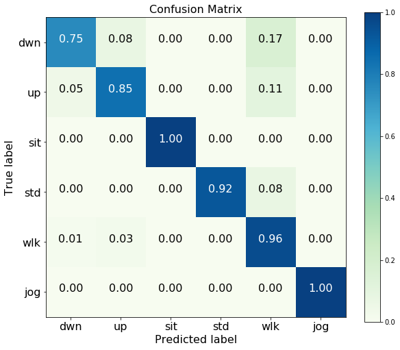

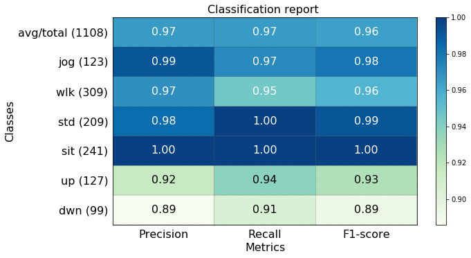

```python
#!/usr/bin/env python3
# -*- coding: utf-8 -*-
"""
Created  September  2017

@author: mmalekzadeh
"""
###############################################################################
import plotcfr
import cnn_act_rec
import numpy as np
###############################################################################

#####################################
# fix random seed for reproducibility
np.random.seed(2017)
#####################################

#### Global Variables ###
sub_id = 4
print("for data subject #",sub_id)

file_name = "secs_data/sub_"+str(sub_id)+"_secs_data.npy"
secs_data = np.load(file_name)
file_name = "secs_data/sub_"+str(sub_id)+"_secs_labels.npy"
secs_labels = np.load(file_name)
num_folds = 5

losses = np.zeros(num_folds)
accuracies = np.zeros(num_folds)
cf_rprt = {}
cf_cfmt = {}

train_data = np.zeros((0, secs_data.shape[1], secs_data.shape[2]))
test_data = np.zeros((0, secs_data.shape[1], secs_data.shape[2]))
train_labels = np.zeros((0))
test_labels = np.zeros((0))
num_classes = np.unique(secs_labels).shape[0]

for fold in range(0,num_folds):

    for c in range(1,num_classes+1):
        c_data = secs_data[secs_labels == c]
        c_labels = secs_labels[secs_labels == c]

        train_data = np.append(train_data,
                               c_data[:round((fold/num_folds)*len(c_data))],
                               axis=0)
        train_labels = np.append(train_labels,
                                 c_labels[:round((fold/num_folds)*len(c_data))],
                                 axis=0)

        test_data = np.append(test_data,
                               c_data[round((fold/num_folds)*len(c_data)):round(((fold+1)/num_folds)*len(c_data))],
                               axis=0)
        test_labels = np.append(test_labels,
                                 c_labels[round((fold/num_folds)*len(c_data)):round(((fold+1)/num_folds)*len(c_data))],
                                 axis=0)

        train_data = np.append(train_data,
                               c_data[round(((fold+1)/num_folds)*len(c_data)):],
                               axis=0)
        train_labels = np.append(train_labels,
                                 c_labels[round(((fold+1)/num_folds)*len(c_data)):],
                                 axis=0)

    ## Because we don't have Null
    train_labels = train_labels -1
    test_labels = test_labels -1

    ## Train Model
    print("_____________________________________________")
    print("Learning on Fold #",(fold+1))
    f_loss, f_accuracy, f_cf_cfmt, f_cf_rprt = cnn_act_rec.train(train_data,
                                                         train_labels,
                                                         test_data,
                                                         test_labels,
                                                         epoc=10,
                                                         vbs=2)

    print("_____________________________________________")
    ## Save results of current fold
    losses[fold] = f_loss
    accuracies[fold] = f_accuracy
    cf_cfmt[fold] = f_cf_cfmt
    cf_rprt[fold] = f_cf_rprt

    train_data = np.zeros((0, secs_data.shape[1], secs_data.shape[2]))
    test_data = np.zeros((0, secs_data.shape[1], secs_data.shape[2]))
    train_labels = np.zeros((0))
    test_labels = np.zeros((0))
    num_classes = np.unique(secs_labels).shape[0]

print("\n***~~~ Overall Results:")
plotcfr.plot(losses, accuracies, cf_cfmt, cf_rprt, num_folds)
```

### Comment :

For data subject #4 average F1-score is %96.

### 2) Homogeneous Training: Train a model for the user with a dataset of subjects that are similar to the user

### Comment :

Now, we assume that #3 is a new user and asks for a service.  
1) Here we suppose that we have no data of the user. So, we want to use existing datasets to train a model for her.  
2) We first train a model on dataset of group A (except #3) as a "SIMILAR" group and then test it on dataset of #3.  
3) Then train a model on dataset of group B as a "Different" group and then test it on dataset of #3.

```
_____________________________________________
Learning on a Similar Group
 - 103s - loss: 0.3635 - acc: 0.8747
 - 102s - loss: 0.1441 - acc: 0.9568
 - 103s - loss: 0.1086 - acc: 0.9662
 - 102s - loss: 0.0859 - acc: 0.9736
 - 117s - loss: 0.0771 - acc: 0.9759
 - 121s - loss: 0.0694 - acc: 0.9797
 - 100s - loss: 0.0621 - acc: 0.9808
 - 107s - loss: 0.0615 - acc: 0.9819
 - 108s - loss: 0.0593 - acc: 0.9821
 - 111s - loss: 0.0537 - acc: 0.9834

 ~~ Result: Loss 0.13

 ~~ Result: Accuracy 95.75%
_____________________________________________

***~~~ Final Results:

 ~~~ Result: Loss [Average of all folds] 0.13

 ~~~ Result: Accuracy [Average of all folds] 95.75%
Normalized confusion matrix
```

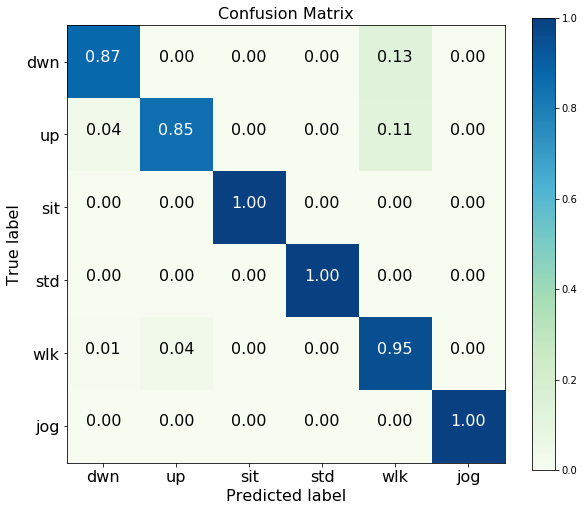

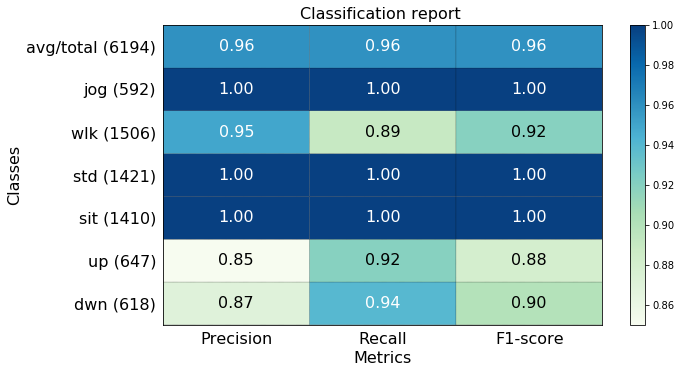

```
_____________________________________________
Learning on a Non-Similar Group
 - 137s - loss: 0.3362 - acc: 0.8781
 - 120s - loss: 0.1607 - acc: 0.9476
 - 119s - loss: 0.1314 - acc: 0.9559
 - 124s - loss: 0.1160 - acc: 0.9609
 - 140s - loss: 0.1073 - acc: 0.9630
 - 155s - loss: 0.0945 - acc: 0.9668
 - 155s - loss: 0.0954 - acc: 0.9679
 - 144s - loss: 0.0892 - acc: 0.9692
 - 145s - loss: 0.0874 - acc: 0.9685
 - 141s - loss: 0.0796 - acc: 0.9721

 ~~ Result: Loss 0.53

 ~~ Result: Accuracy 85.99%
_____________________________________________

***~~~ Final Results:

 ~~~ Result: Loss [Average of all folds] 0.53

 ~~~ Result: Accuracy [Average of all folds] 85.99%
Normalized confusion matrix
```

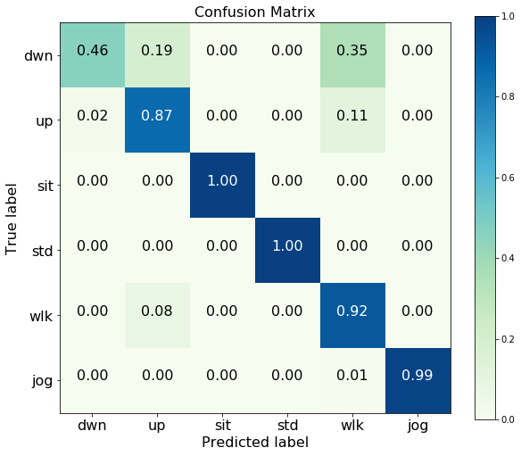

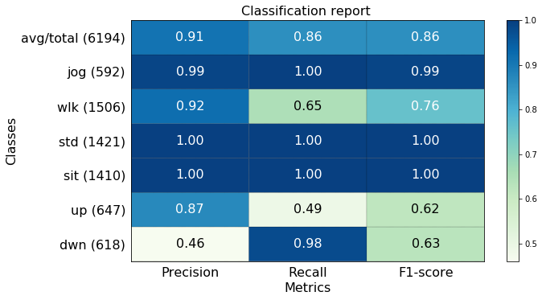

```python
#!/usr/bin/env python3
# -*- coding: utf-8 -*-
"""
Created  September  2017

@author: mmalekzadeh
"""
###############################################################################
import plotcfr
import cnn_act_rec
import matplotlib.pyplot as plt
import numpy as np
###############################################################################

#####################################
# fix random seed for reproducibility
np.random.seed(2017)
#####################################
#### Global Variables ###

main_sub_id = 3
df_name = "secs_data/sub_"+str(main_sub_id)+"_secs_data.npy"
main_secs_data = np.load(df_name)
lf_name = "secs_data/sub_"+str(main_sub_id)+"_secs_labels.npy"
main_secs_labels = np.load(lf_name)

similar_sub_ids = [5,7,8,18]
similar_secs_data = np.array([])
similar_secs_labels = np.array([])
for indx,sid in enumerate(similar_sub_ids):
    df_name = "secs_data/sub_"+str(sid)+"_secs_data.npy"
    lf_name = "secs_data/sub_"+str(sid)+"_secs_labels.npy"
    if(similar_secs_data.size == 0):
        similar_secs_data = np.load(df_name)
        similar_secs_labels = np.load(lf_name)
    else:
        similar_secs_data = np.append(similar_secs_data, np.load(df_name), axis=0)
        similar_secs_labels = np.append(similar_secs_labels, np.load(lf_name), axis=0)


different_sub_ids = [4,6,9,20,22]
different_secs_data = np.array([])
different_secs_labels = np.array([])
for indx,sid in enumerate(different_sub_ids):
    df_name = "secs_data/sub_"+str(sid)+"_secs_data.npy"
    lf_name = "secs_data/sub_"+str(sid)+"_secs_labels.npy"
    if(different_secs_data.size == 0):
        different_secs_data = np.load(df_name)
        different_secs_labels = np.load(lf_name)
    else:
        different_secs_data = np.append(different_secs_data, np.load(df_name), axis=0)
        different_secs_labels = np.append(different_secs_labels, np.load(lf_name), axis=0)


num_folds =1
losses = np.zeros(num_folds)
accuracies = np.zeros(num_folds)
cf_rprt = {}
cf_cfmt = {}

## Train Model on Similar
print("_____________________________________________")
print("Learning on a Similar Group")
train_data = similar_secs_data
test_data = main_secs_data
train_labels = similar_secs_labels
test_labels = main_secs_labels
## Because we don't have Null
train_labels = train_labels -1
test_labels = test_labels -1
f_loss, f_accuracy, f_cf_cfmt, f_cf_rprt = cnn_act_rec.train(train_data,
                                                             train_labels,
                                                             test_data,
                                                             test_labels,
                                                             epoc=10,
                                                             vbs=2)

print("_____________________________________________")
losses[0] = f_loss
accuracies[0] = f_accuracy
cf_cfmt[0] = f_cf_cfmt
cf_rprt[0] = f_cf_rprt
print("\n***~~~ Final Results:")
plotcfr.plot(losses, accuracies, cf_cfmt, cf_rprt, num_folds)

## Train Model on Different
print("_____________________________________________")
print("Learning on a Non-Similar Group")
train_data = different_secs_data
test_data = main_secs_data
train_labels = different_secs_labels
test_labels = main_secs_labels
## Because we don't have Null
train_labels = train_labels -1
test_labels = test_labels -1
f_loss, f_accuracy, f_cf_cfmt, f_cf_rprt = cnn_act_rec.train(train_data,
                                                             train_labels,
                                                             test_data,
                                                             test_labels,
                                                             epoc=10,
                                                             vbs=2)

print("_____________________________________________")
losses[0] = f_loss
accuracies[0] = f_accuracy
cf_cfmt[0] = f_cf_cfmt
cf_rprt[0] = f_cf_rprt
print("\n***~~~ Final Results:")
plotcfr.plot(losses, accuracies, cf_cfmt, cf_rprt, num_folds)
```

### Comment:

```
_____________________________________________
Learning on a Similar Group
 - 98s - loss: 0.3469 - acc: 0.8767
 - 91s - loss: 0.1582 - acc: 0.9488
 - 92s - loss: 0.1233 - acc: 0.9576
 - 98s - loss: 0.1083 - acc: 0.9633
 - 99s - loss: 0.1015 - acc: 0.9657
 - 100s - loss: 0.0898 - acc: 0.9691
 - 104s - loss: 0.0833 - acc: 0.9716
 - 119s - loss: 0.0804 - acc: 0.9717
 - 95s - loss: 0.0763 - acc: 0.9719
 - 90s - loss: 0.0732 - acc: 0.9731

 ~~ Result: Loss 0.46

 ~~ Result: Accuracy 89.30%
_____________________________________________

***~~~ Final Results:

 ~~~ Result: Loss [Average of all folds] 0.46

 ~~~ Result: Accuracy [Average of all folds] 89.30%
Normalized confusion matrix
```

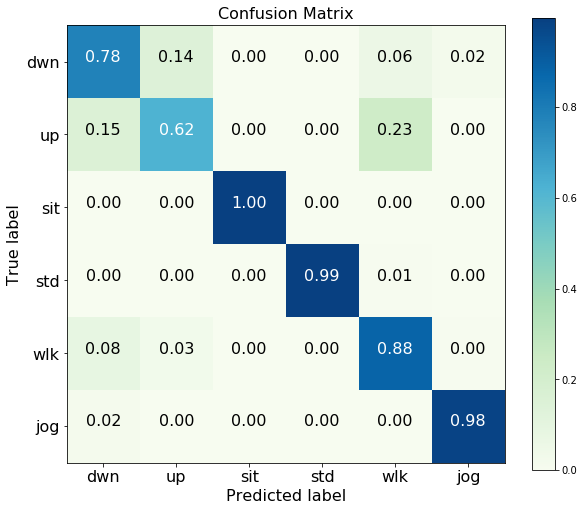

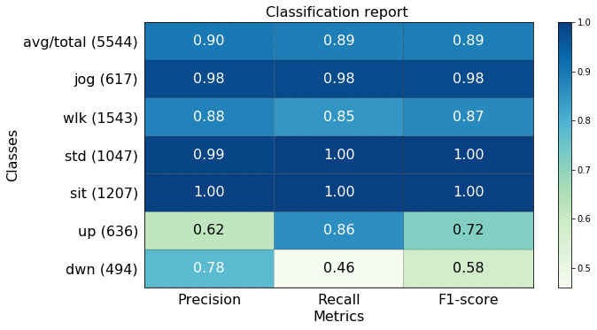

```
_____________________________________________
Learning on a Non-Similar Group
 - 137s - loss: 0.3128 - acc: 0.8921
 - 124s - loss: 0.1263 - acc: 0.9622
 - 124s - loss: 0.0992 - acc: 0.9698
 - 130s - loss: 0.0777 - acc: 0.9773
 - 134s - loss: 0.0745 - acc: 0.9779
 - 147s - loss: 0.0659 - acc: 0.9807
 - 144s - loss: 0.0613 - acc: 0.9811
 - 146s - loss: 0.0575 - acc: 0.9825
 - 153s - loss: 0.0565 - acc: 0.9827
 - 138s - loss: 0.0535 - acc: 0.9848

 ~~ Result: Loss 0.50

 ~~ Result: Accuracy 81.06%
_____________________________________________

***~~~ Final Results:

 ~~~ Result: Loss [Average of all folds] 0.50

 ~~~ Result: Accuracy [Average of all folds] 81.06%
Normalized confusion matrix
```

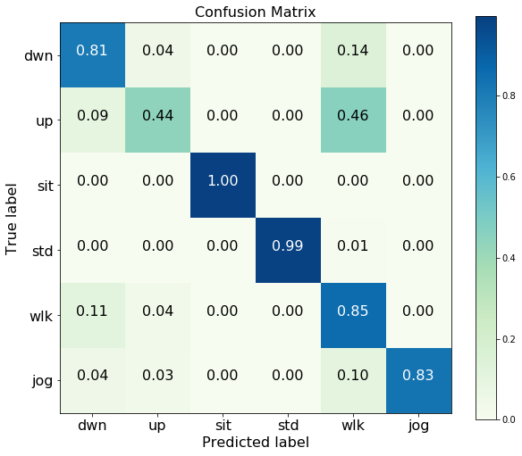

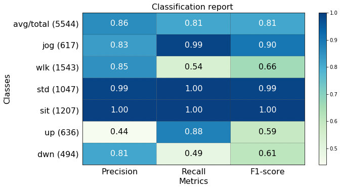

```python
#!/usr/bin/env python3
# -*- coding: utf-8 -*-
"""
Created  September  2017

@author: mmalekzadeh
"""
###############################################################################
import plotcfr
import cnn_act_rec
import matplotlib.pyplot as plt
import numpy as np
###############################################################################

#####################################
# fix random seed for reproducibility
np.random.seed(2017)
#####################################
#### Global Variables ###

main_sub_id = 4
df_name = "secs_data/sub_"+str(main_sub_id)+"_secs_data.npy"
main_secs_data = np.load(df_name)
lf_name = "secs_data/sub_"+str(main_sub_id)+"_secs_labels.npy"
main_secs_labels = np.load(lf_name)

similar_sub_ids = [6,9,20,22]
similar_secs_data = np.array([])
similar_secs_labels = np.array([])
for indx,sid in enumerate(similar_sub_ids):
    df_name = "secs_data/sub_"+str(sid)+"_secs_data.npy"
    lf_name = "secs_data/sub_"+str(sid)+"_secs_labels.npy"
    if(similar_secs_data.size == 0):
        similar_secs_data = np.load(df_name)
        similar_secs_labels = np.load(lf_name)
    else:
        similar_secs_data = np.append(similar_secs_data, np.load(df_name), axis=0)
        similar_secs_labels = np.append(similar_secs_labels, np.load(lf_name), axis=0)


different_sub_ids = [3,5,7,8,18]
different_secs_data = np.array([])
different_secs_labels = np.array([])
for indx,sid in enumerate(different_sub_ids):
    df_name = "secs_data/sub_"+str(sid)+"_secs_data.npy"
    lf_name = "secs_data/sub_"+str(sid)+"_secs_labels.npy"
    if(different_secs_data.size == 0):
        different_secs_data = np.load(df_name)
        different_secs_labels = np.load(lf_name)
    else:
        different_secs_data = np.append(different_secs_data, np.load(df_name), axis=0)
        different_secs_labels = np.append(different_secs_labels, np.load(lf_name), axis=0)


num_folds =1
losses = np.zeros(num_folds)
accuracies = np.zeros(num_folds)
cf_rprt = {}
cf_cfmt = {}

## Train Model on Similar
print("_____________________________________________")
print("Learning on a Similar Group")
train_data = similar_secs_data
test_data = main_secs_data
train_labels = similar_secs_labels
test_labels = main_secs_labels
## Because we don't have Null
train_labels = train_labels -1
test_labels = test_labels -1
f_loss, f_accuracy, f_cf_cfmt, f_cf_rprt = cnn_act_rec.train(train_data,
                                                             train_labels,
                                                             test_data,
                                                             test_labels,
                                                             epoc=10,
                                                             vbs=2)

print("_____________________________________________")
losses[0] = f_loss
accuracies[0] = f_accuracy
cf_cfmt[0] = f_cf_cfmt
cf_rprt[0] = f_cf_rprt
print("\n***~~~ Final Results:")
plotcfr.plot(losses, accuracies, cf_cfmt, cf_rprt, num_folds)

## Train Model on Different
print("_____________________________________________")
print("Learning on a Non-Similar Group")
train_data = different_secs_data
test_data = main_secs_data
train_labels = different_secs_labels
test_labels = main_secs_labels
## Because we don't have Null
train_labels = train_labels -1
test_labels = test_labels -1
f_loss, f_accuracy, f_cf_cfmt, f_cf_rprt = cnn_act_rec.train(train_data,
                                                             train_labels,
                                                             test_data,
                                                             test_labels,
                                                             epoc=10,
                                                             vbs=2)

print("_____________________________________________")
losses[0] = f_loss
accuracies[0] = f_accuracy
cf_cfmt[0] = f_cf_cfmt
cf_rprt[0] = f_cf_rprt
print("\n***~~~ Final Results:")
plotcfr.plot(losses, accuracies, cf_cfmt, cf_rprt, num_folds)
```

### 3) General Training: train a model for the user with all the existing data.

### Comment:

Let's look at data subject #3 when we train a model for her with all the data : {Group A U Group B}

```
_____________________________________________
Learning on a All
 - 202s - loss: 0.3074 - acc: 0.8930
 - 200s - loss: 0.1510 - acc: 0.9519
 - 204s - loss: 0.1192 - acc: 0.9618
 - 203s - loss: 0.1068 - acc: 0.9653
 - 200s - loss: 0.0957 - acc: 0.9695
 - 201s - loss: 0.0919 - acc: 0.9712
 - 200s - loss: 0.0853 - acc: 0.9724
 - 214s - loss: 0.0789 - acc: 0.9745
 - 197s - loss: 0.0767 - acc: 0.9752
 - 195s - loss: 0.0704 - acc: 0.9774

 ~~ Result: Loss 0.22

 ~~ Result: Accuracy 91.22%
_____________________________________________

***~~~ Final Results:

 ~~~ Result: Loss [Average of all folds] 0.22

 ~~~ Result: Accuracy [Average of all folds] 91.22%
Normalized confusion matrix
```

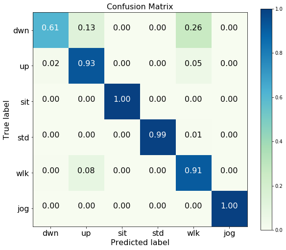

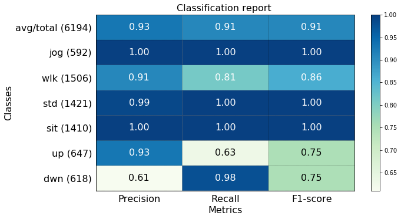

```python
#!/usr/bin/env python3
# -*- coding: utf-8 -*-
"""
Created  September  2017

@author: mmalekzadeh
"""
###############################################################################
import plotcfr
import cnn_act_rec
import matplotlib.pyplot as plt
import numpy as np
###############################################################################

#####################################
# fix random seed for reproducibility
np.random.seed(2017)
#####################################
#### Global Variables ###

main_sub_id = 3
df_name = "secs_data/sub_"+str(main_sub_id)+"_secs_data.npy"
main_secs_data = np.load(df_name)
lf_name = "secs_data/sub_"+str(main_sub_id)+"_secs_labels.npy"
main_secs_labels = np.load(lf_name)

all_sub_ids = [5,7,8,18,6,9,20,22]
all_secs_data = np.array([])
all_secs_labels = np.array([])
for indx,sid in enumerate(all_sub_ids):
    df_name = "secs_data/sub_"+str(sid)+"_secs_data.npy"
    lf_name = "secs_data/sub_"+str(sid)+"_secs_labels.npy"
    if(all_secs_data.size == 0):
        all_secs_data = np.load(df_name)
        all_secs_labels = np.load(lf_name)
    else:
        all_secs_data = np.append(all_secs_data, np.load(df_name), axis=0)
        all_secs_labels = np.append(all_secs_labels, np.load(lf_name), axis=0)


num_folds =1
losses = np.zeros(num_folds)
accuracies = np.zeros(num_folds)
cf_rprt = {}
cf_cfmt = {}

## Train Model on All
print("_____________________________________________")
print("Learning on a All")
train_data = all_secs_data
test_data = main_secs_data
train_labels = all_secs_labels
test_labels = main_secs_labels
## Because we don't have Null
train_labels = train_labels -1
test_labels = test_labels -1
f_loss, f_accuracy, f_cf_cfmt, f_cf_rprt = cnn_act_rec.train(train_data,
                                                             train_labels,
                                                             test_data,
                                                             test_labels,
                                                             epoc=10,
                                                             vbs=2)

print("_____________________________________________")
losses[0] = f_loss
accuracies[0] = f_accuracy
cf_cfmt[0] = f_cf_cfmt
cf_rprt[0] = f_cf_rprt
print("\n***~~~ Final Results:")
plotcfr.plot(losses, accuracies, cf_cfmt, cf_rprt, num_folds)
```

### Comment:

Here, the average F1-Score is %91.  
So, let's have a look at the result of these four exp:  
1) personal training: %97  
2) Homogeneous training: %96  
3) Heterogeneous training: 86%  
4) General training: %91  
Let's see the result for data subject #4

```
_____________________________________________
Learning on a All
 - 214s - loss: 0.3077 - acc: 0.8929
 - 216s - loss: 0.1492 - acc: 0.9521
 - 206s - loss: 0.1204 - acc: 0.9622
 - 201s - loss: 0.1066 - acc: 0.9665
 - 202s - loss: 0.0952 - acc: 0.9697
 - 201s - loss: 0.0896 - acc: 0.9713
 - 199s - loss: 0.0866 - acc: 0.9728
 - 193s - loss: 0.0798 - acc: 0.9743
 - 193s - loss: 0.0766 - acc: 0.9753
 - 193s - loss: 0.0713 - acc: 0.9763

 ~~ Result: Loss 0.25

 ~~ Result: Accuracy 91.11%
_____________________________________________

***~~~ Final Results:

 ~~~ Result: Loss [Average of all folds] 0.25

 ~~~ Result: Accuracy [Average of all folds] 91.11%
Normalized confusion matrix
```

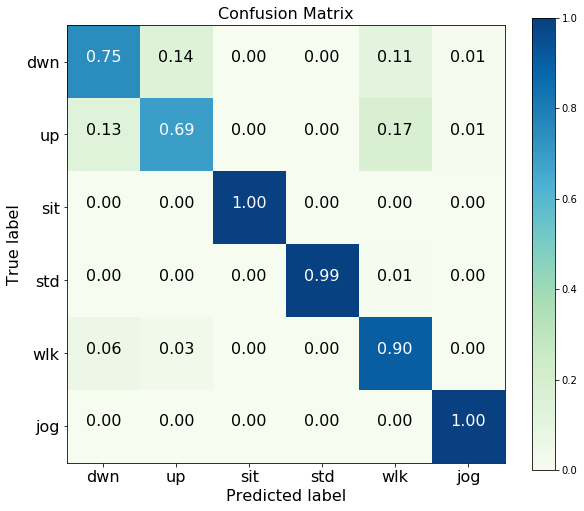

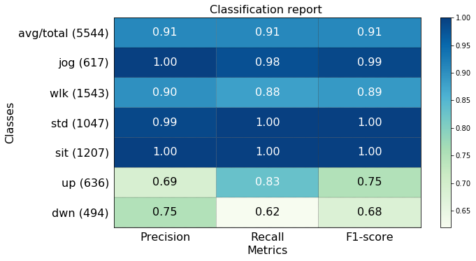

```python
#!/usr/bin/env python3
# -*- coding: utf-8 -*-
"""
Created  September  2017

@author: mmalekzadeh
"""
###############################################################################
import plotcfr
import cnn_act_rec
import matplotlib.pyplot as plt
import numpy as np
###############################################################################

#####################################
# fix random seed for reproducibility
np.random.seed(2017)
#####################################
#### Global Variables ###

main_sub_id = 4
df_name = "secs_data/sub_"+str(main_sub_id)+"_secs_data.npy"
main_secs_data = np.load(df_name)
lf_name = "secs_data/sub_"+str(main_sub_id)+"_secs_labels.npy"
main_secs_labels = np.load(lf_name)

all_sub_ids = [5,7,8,18,6,9,20,22]
all_secs_data = np.array([])
all_secs_labels = np.array([])
for indx,sid in enumerate(all_sub_ids):
    df_name = "secs_data/sub_"+str(sid)+"_secs_data.npy"
    lf_name = "secs_data/sub_"+str(sid)+"_secs_labels.npy"
    if(all_secs_data.size == 0):
        all_secs_data = np.load(df_name)
        all_secs_labels = np.load(lf_name)
    else:
        all_secs_data = np.append(all_secs_data, np.load(df_name), axis=0)
        all_secs_labels = np.append(all_secs_labels, np.load(lf_name), axis=0)


num_folds =1
losses = np.zeros(num_folds)
accuracies = np.zeros(num_folds)
cf_rprt = {}
cf_cfmt = {}

## Train Model on All
print("_____________________________________________")
print("Learning on a All")
train_data = all_secs_data
test_data = main_secs_data
train_labels = all_secs_labels
test_labels = main_secs_labels
## Because we don't have Null
train_labels = train_labels -1
test_labels = test_labels -1
f_loss, f_accuracy, f_cf_cfmt, f_cf_rprt = cnn_act_rec.train(train_data,
                                                             train_labels,
                                                             test_data,
                                                             test_labels,
                                                             epoc=10,
                                                             vbs=2)

print("_____________________________________________")
losses[0] = f_loss
accuracies[0] = f_accuracy
cf_cfmt[0] = f_cf_cfmt
cf_rprt[0] = f_cf_rprt
print("\n***~~~ Final Results:")
plotcfr.plot(losses, accuracies, cf_cfmt, cf_rprt, num_folds)
```

### Comment:

So, for #4 is almost same:  
1) personal training: %96  
2) Homogeneous training: %89  
3) Heterogeneous training: 81%  
4) General training: %91